# results and discussion outline

## 3. Interannual changes to carbon fluxes during drought

When looking at changes in transpiration, there are minimal differences across temperature scenarios and trees during drought years. This is likely due to transpiration demands exceeding water availability, so all of the water is used no matter the temperature or tree parameters.

For the below plot, we took the median daily carbon fluxes across all parameter ensembles for each temperature scenario. We separated into drought and wet years, where drought years include 2012-2016 and wet years include 2011 and 2017.

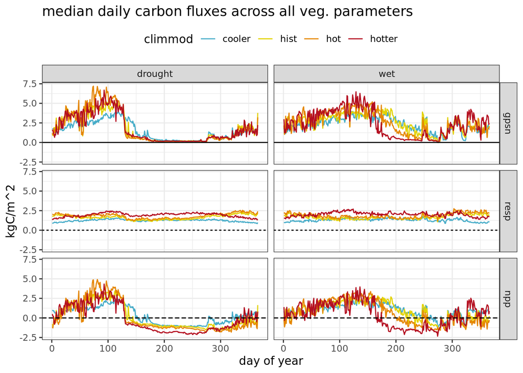

### Seasonal differences in GPSN scross scenarios

To further explore the changes to seasonal carbon fluxes during drought, we calculated changes in peak gross photosynthesis for each species parameter ensemble and temperature scenario. We looked at the day of the year when 50% of GPSN is reached to see how drought changes the timing of productivity.

- During drought years, half of the GPSN is reached earlier in the year compared to wet years
- The changes between tree species may have to do with the leaf-on and leaf-off periods set in the model
- cooler temperatures have longer periods of GPSN through the year, but lower net amounts, while warmer temperatures have higher net amounts, but a shorter season.

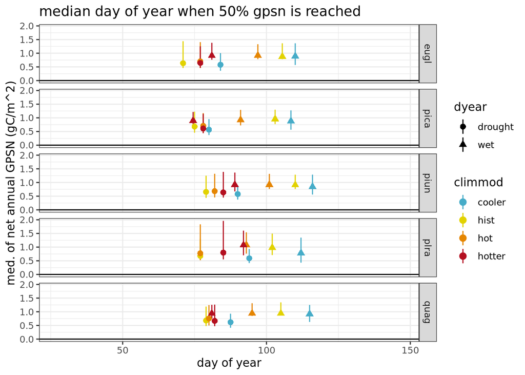